# La demografía del parentesco: una introducción práctica

#### 2. Modelos de parentesco de dos sexos invariantes en el tiempo

Ahora presentamos las funciones `kin2sex`, que es similar a la función de un solo sexo `kin` (consultar `?kin2sex`) con dos excepciones. En primer lugar, el usuario debe especificar la mortalidad y la fecundidad por sexo. En segundo lugar, se debe indicar el sexo de Focal (que se asume que es femenino de forma predeterminada, al igual que en el modelo de un solo sexo). Primero, consideremos la aplicación para poblaciones invariantes en el tiempo:

```r
fra_kin_2sex <- kin2sex(
  pf = fra_surv_f,
  pm = fra_surv_m,
  ff = fra_fert_f,
  fm = fra_fert_m,
  time_invariant = TRUE,
  sex_focal = "f",
  birth_female = .5)
```

La salida de `kin2sex` es equivalente a la de `kin`, excepto que incluye una columna `sex_kin` para especificar el sexo de los parientes dados. Eche un vistazo con `head(fra_kin_2sex$kin_summary)`.

> Una nota sobre la terminología: La función `kin2sex` utiliza los mismos códigos que `kin` para identificar parientes (consultar `demokin_codes`). ¡Tenga en cuenta que al ejecutar un modelo de dos sexos, el código ‘m’ se refiere tanto a madres como a padres! Utilice la columna `sex_kin` para filtrar el sexo de los parientes dados.

Por ejemplo, para considerar solo a los hijos e ignorar a las hijas, use:

```r
fra_kin_2sex$kin_summary %>%
  filter(kin == "d", sex_kin == "m") %>%
  head()
```

```
## # A tibble: 6 × 11
##   age_focal kin   sex_kin year  cohort count_li…¹ mean_…² sd_age count…³ count…⁴
##       <int> <chr> <chr>   <lgl> <lgl>       <dbl>   <dbl>  <dbl>   <dbl>   <dbl>
## 1         0 d     m       NA    NA              0     NaN    NaN       0       0
## 2         1 d     m       NA    NA              0     NaN    NaN       0       0
## 3         2 d     m       NA    NA              0     NaN    NaN       0       0
## 4         3 d     m       NA    NA              0     NaN    NaN       0       0
## 5         4 d     m       NA    NA              0     NaN    NaN       0       0
## 6         5 d     m       NA    NA              0     NaN    NaN       0       0
## # … with 1 more variable: mean_age_lost <dbl>, and abbreviated variable names
## #   ¹count_living, ²mean_age, ³count_dead, ⁴count_cum_dead
```

Agrupemos a las tías y a los hermanos y visualicemos el número de parientes vivos por sexo y edad de Focal.

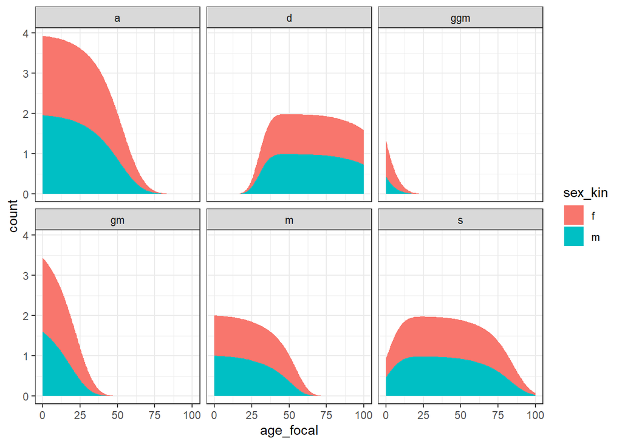

```r
kin_out <- fra_kin_2sex$kin_summary %>%
  mutate(kin = case_when(kin %in% c("os", "ys") ~ "s",
                         kin %in% c("ya", "oa") ~ "a",
                         TRUE ~ kin)) %>%
  filter(kin %in% c("d", "m", "gm", "ggm", "s", "a"))

kin_out %>%
  summarise(count=sum(count_living), .by = c(kin, age_focal, sex_kin)) %>%
  ggplot(aes(age_focal, count, fill=sex_kin))+
  geom_area()+
  theme_bw() +
  facet_wrap(~kin)
```

La información sobre la disponibilidad de parientes por sexo nos permite considerar las proporciones sexuales (sex ratio), una medida tradicional en demografía, con las mujeres a menudo en el denominador. La siguiente figura, por ejemplo, muestra que una mujer francesa de 25 años en nuestra población hipotética puede esperar tener 0.5 abuelos por cada abuela. ¿Siempre ocurre que la proporción sexuales disminuye con la edad de Focal?

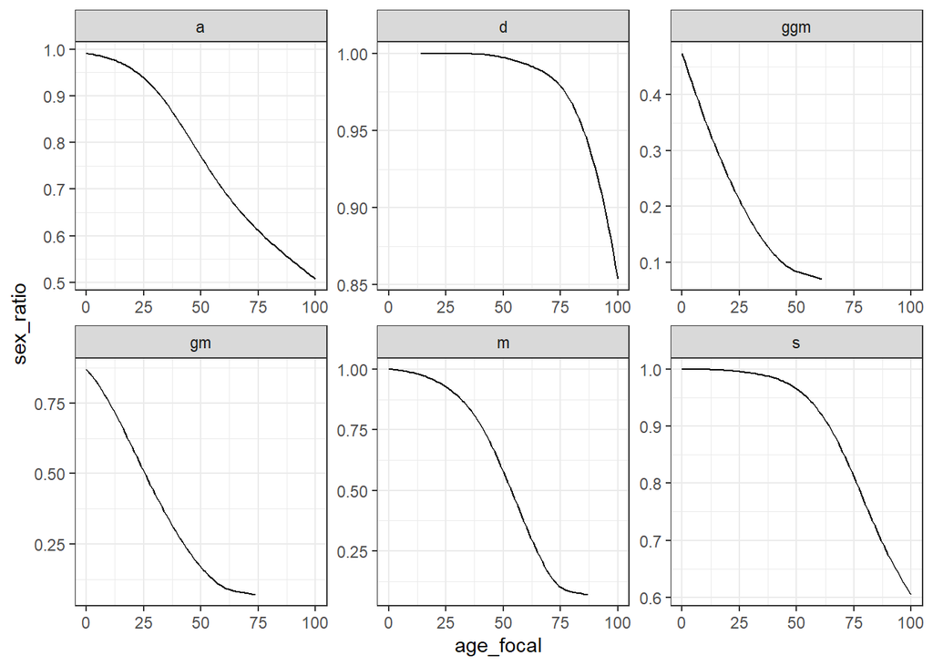

```r
kin_out %>%
  group_by(kin, age_focal) %>%
  summarise(sex_ratio = sum(count_living[sex_kin=="m"], na.rm=TRUE)/sum(count_living[sex_kin=="f"], na.rm=TRUE)) %>%
  ggplot(aes(age_focal, sex_ratio))+
  geom_line()+
  theme_bw() +
  facet_wrap(~kin, scales = "free")
```

**Responde:** ¿Debería ser el número total de tías vivas el mismo en el modelo de un solo sexo en comparación con los modelos de dos sexos? ¿Qué pasa con las hijas?

La experiencia de la pérdida de parientes para Focal depende de las diferencias en la mortalidad entre los sexos. Una Focal femenina comienza a perder padres antes que madres. Observamos un patrón ligeramente diferente para los abuelos, ya que la experiencia de Focal de la pérdida de abuelos depende de la disponibilidad inicial de abuelos (es decir, si el abuelo de Focal murió antes de su nacimiento, ella nunca experimentará su muerte). ¿Queda esto claro?

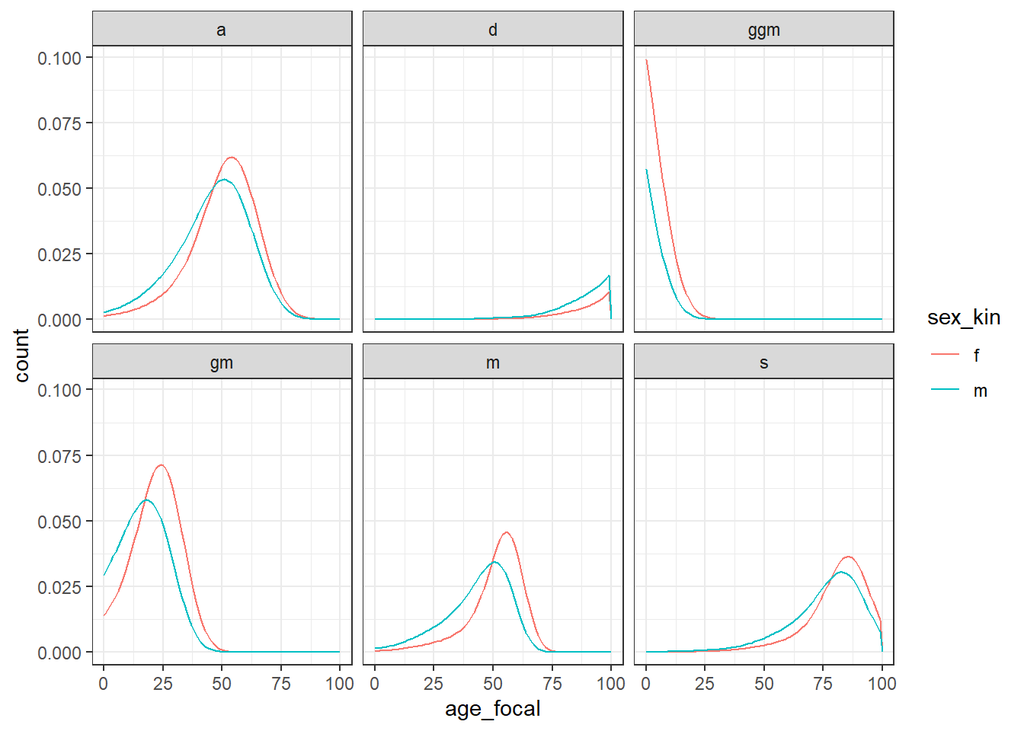

```r
kin_out %>%
  summarise(count=sum(count_dead), .by = c(kin, sex_kin, age_focal)) %>%
  ggplot(aes(age_focal, count, col=sex_kin))+
  geom_line()+
  theme_bw() +
  facet_wrap(~kin)
```

#### 3. Modelos de parentesco de dos sexos variantes en el tiempo

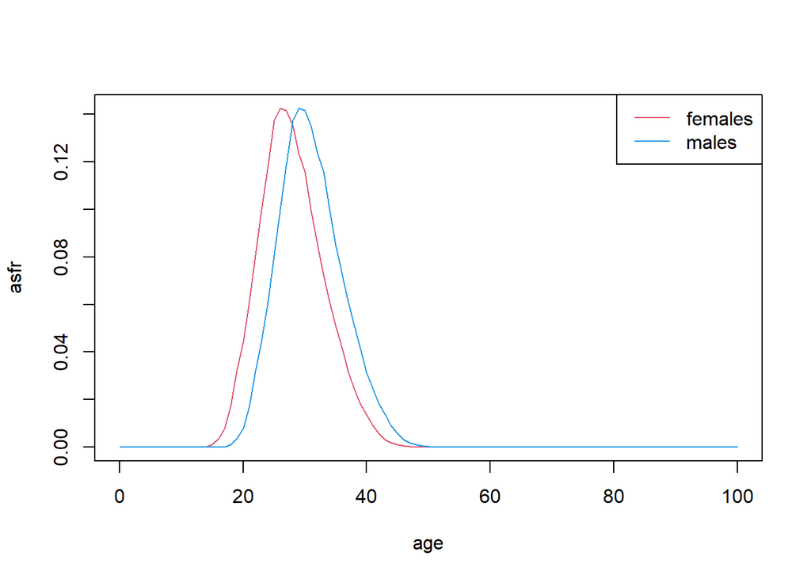

```r
load("../data/fra_2sex.Rdata")
years <- ncol(fra_asfr_females)
ages <- nrow(fra_asfr_females)

# diferencia entre sexos en la edad media en 2012
mac_females_2012 <- sum(0:100 * fra_fert_f)/sum(fra_fert_f)
mac_males_2012   <- sum(0:100 * fra_fert_m)/sum(fra_fert_m)
dif_mac_2012     <- trunc(mac_males_2012 - mac_females_2012)

# crear una matriz de fecundidad masculina
fra_asfr_males <- matrix(0, ages, years)
colnames(fra_asfr_males) <- colnames(fra_asfr_females)
fra_asfr_males[(dif_mac_2012+1):ages,] <- fra_asfr_females[1:(ages-dif_mac_2012),]

# graficar un año
plot(age, fra_asfr_females[,"1990"], t="l", col=2, ylab = "asfr")
lines(age, fra_asfr_males[,"1990"], col=4)
legend("topright", c("females", "males"), col=c(2,4), lty=1)
```

Ahora ejecutamos los modelos de parentesco de dos sexos variantes en el tiempo (nota el argumento `time_invariant = FALSE`):

```r
kin_out_time_variant <- kin2sex(
                      pf = fra_surv_females,
                      pm = fra_surv_males,
                      ff = fra_asfr_females,
                      fm = fra_asfr_males,
                      sex_focal = "f",
                      time_invariant = FALSE,
                      birth_female = .5,
                      output_cohort = 1950)
```

```
## Preparing output...
```

```
## Assuming stable population before 1950.
```

Podemos graficar los datos de disponibilidad de parientes junto con los valores provenientes de un modelo invariante en el tiempo para mostrar cómo importa el cambio demográfico: los modelos variantes en el tiempo tienen en cuenta los cambios derivados de la transición demográfica, mientras que los modelos invariantes en el tiempo asumen tasas que no cambian nunca. ¿Los efectos son los mismos para cada sexo?

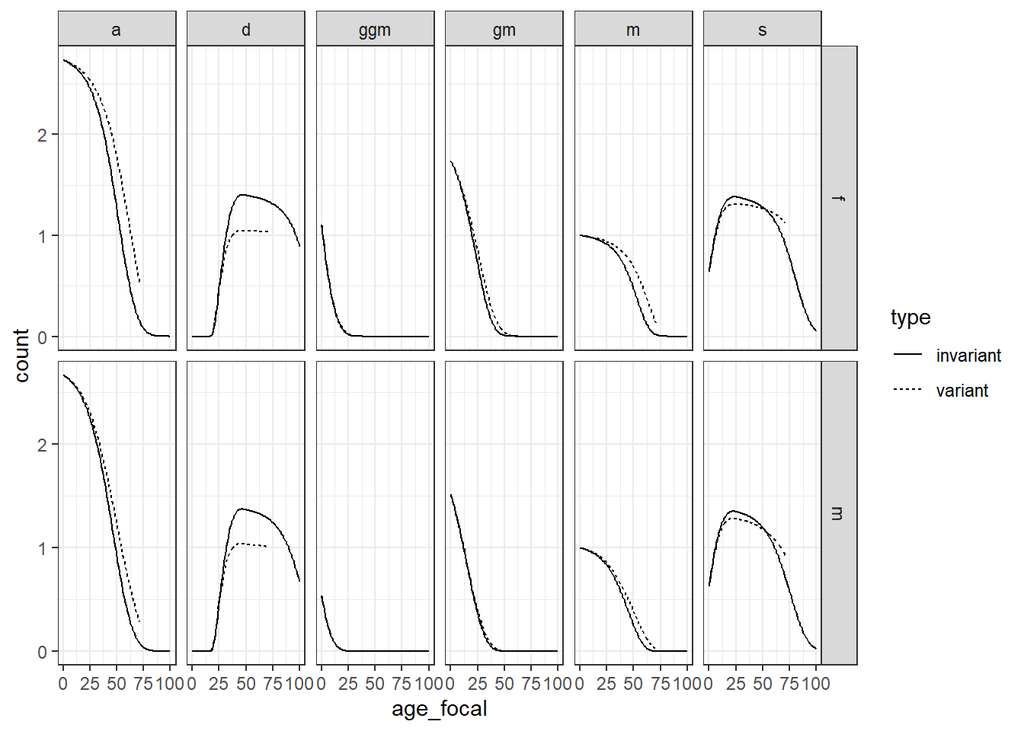

```r
kin_out_time_invariant <- kin2sex(
                      pf = fra_surv_females[,"1950"],
                      pm = fra_surv_males[,"1950"],
                      ff = fra_asfr_females[,"1950"],
                      fm = fra_asfr_males[,"1950"],
                      time_invariant = TRUE,
                      sex_focal = "f", birth_female = .5)

kin_out_time_variant$kin_summary %>%
  filter(cohort == 1950) %>% mutate(type = "variant") %>%
  bind_rows(kin_out_time_invariant$kin_summary %>% mutate(type = "invariant")) %>%
  mutate(kin = case_when(kin %in% c("ys", "os") ~ "s",
                         kin %in% c("ya", "oa") ~ "a",
                         T ~ kin)) %>%
  filter(kin %in% c("d", "m", "gm", "ggm", "s", "a")) %>%
  group_by(type, kin, age_focal, sex_kin) %>%
  summarise(count=sum(count_living)) %>%
  ggplot(aes(age_focal, count, linetype=type))+
  geom_line()+ theme_bw() +
  facet_grid(cols = vars(kin), rows=vars(sex_kin), scales = "free")
```

> Una nota de interpretación: no estamos rastreando la línea de descendencia o ascendencia. Esto significa que, por ejemplo, no se puede diferenciar a las nietas si son descendientes del hijo de la Focal o de la hija de la Focal. Puedes visualizar esto examinando los resultados de DemoKin y relacionando qué datos puedes construir con las variables reales. Si deseas diferenciar las líneas, probablemente la sección “By hand” puede ser un buen primer paso.

### Ejercicios

#### Parientes vivos por sexo

**E1** Descarga los datos de tu país desde [DataPortal API](https://population.un.org/dataportal/about/dataapi) de la División de Población de las Naciones Unidas. Pero esta vez también utiliza el parámetro `sex = "Male"` porque necesitarás patrones de supervivencia específicos por edad y tiempo para hombres (este parámetro está configurado de forma predeterminada como `sex = "Female"`). No olvides remodelar los datos al formato de matriz como hicimos ayer. Asume para este ejercicio el mismo patrón de fecundidad para hombres que para mujeres y responde:

```r
# Escribe tu código aquí
```

**E1.1** En un modelo invariante en el tiempo: ¿cuántas abuelas y abuelos vivos puede esperar tener una mujer a los 15 años en 1950 y en 2015, y cuál es su edad media? Extrae una conclusión basada en los resultados.

```r
# Escribe tu código aquí
```

**E1.2** Compara las ‘proporciones sexuales’ (sex ratios) de los abuelos, padres, hijas e hermanos en un marco temporal variable para la cohorte 1950, en cada edad de la Focal (p. Ej., la proporcion de abuelos a abuelas).

```r
# Escribe tu código aquí
```

#### Estructuras de parentesco modeladas y observadas

**E2** Utilizarás datos sobre estructuras de parentesco (Kolk et al. 2021) para evaluar modelos formales de parentesco.

```r
kolk <- read.csv("../data/kolk_all_kin.csv", stringsAsFactors = F, skip = 0)
head(kolk)
```

```
##   cohort     mean           kin
## 1   1915 1.185348 grandchildren
## 2   1916 1.885366 grandchildren
## 3   1917 1.872828 grandchildren
## 4   1918 1.935627 grandchildren
## 5   1919 1.927673 grandchildren
## 6   1920 1.873140 grandchildren
```

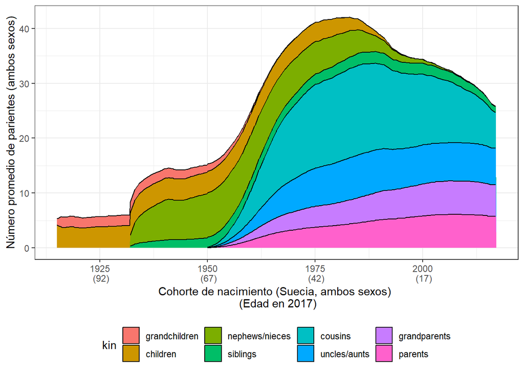

Número promedio de parientes para la población completa de Suecia en 2017 según Kolk et al. (2021) utilizando datos de registros de población. Las cuentas de parentesco se refieren a parientes femeninos y masculinos.

```r
levs <- c("grandchildren", "children", "nephews/nieces", "siblings", "cousins", "uncles/aunts", "grandparents", "parents")
kolk_plot <- kolk %>%
  mutate(kin = factor(kin, levels = levs)) %>%
  ggplot(aes(x = cohort, y = mean, group = kin, fill = kin)) +
  geom_area(colour = "black") +
  scale_x_continuous(labels = function(x) paste0(x, "\n (", 2017 - x, ")")) +
  labs(y = "Número promedio de parientes (ambos sexos)",
       x = "Cohorte de nacimiento (Suecia, ambos sexos) \n (Edad en 2017)") +
  theme_bw() +
  theme(legend.position = "bottom")
kolk_plot
```

La figura anterior muestra la distribución empírica de parentesco para la población de Suecia en 2017 basada en datos de registros. Ten en cuenta que la figura incluye parientes femeninos y masculinos, y que no se especifica el sexo del individuo focal (es decir, es el promedio de todos los individuos masculinos y femeninos en los registros).

Para este ejercicio, debes utilizar `DemoKin` para replicar esta figura. Concretamente, ejecuta tres iteraciones del modelo de parentesco:

1. Modelo de un solo sexo; tasas invariables en el tiempo; factores GKP.
2. Modelo de dos sexos; tasas variables en el tiempo; aproximación del parentesco masculino utilizando la suposición andrógina (es decir, la fecundidad masculina es equivalente a la fecundidad femenina); utiliza tasas de mortalidad para hombres y mujeres.
3. Modelo de dos sexos; tasas variables en el tiempo; utiliza tasas reales de fecundidad masculina y femenina.

Aquí tienes un resumen de las especificaciones del modelo:

```r
data.frame(
`ID` = 1:3
  , `Tiempo` = c("invariante", "variante", "variante")
  , `Sexo` = c("un solo sexo", "dos sexos", "dos sexos")
  , `Aprox.` = c("GKP", "fecundidad andrógina", "Ninguna")
) %>% knitr::kable(format = "simple")
```

| ID | Tiempo | Sexo | Aprox. |
| --- | --- | --- | --- |
| 1 | invariante | un solo sexo | GKP |
| 2 | variante | dos sexos | fecundidad andrógina |
| 3 | variante | dos sexos | Ninguna |

Los datos de mortalidad y fecundidad femenina ya están incluidos en `DemoKin`. Para los hombres, puedes acceder a un archivo llamado “swe_males.Rdata” en la carpeta de datos, con probabilidades de supervivencia y tasas de fecundidad específicas por edad. Estos son **todos los datos que necesitas**. ¿De dónde provienen estos datos? Consulta:

- La fecundidad masculina se descargó del sitio [Human Fertility Collection](https://www.fertilitydata.org/Home/Index), utilizando el siguiente comando en R `read.table("https://www.fertilitydata.org/File/GetFile/Country/males/SWE/m_SWE_ASFRstand_TOT.txt", sep = ",", header = T)`. El rango de años es 1751-2020.
- La supervivencia masculina se descargó de HMD utilizando el paquete `HMDHFDplus`, echa un vistazo [aquí](https://cran.r-project.org/web/packages/HMDHFDplus/HMDHFDplus.pdf). El rango de años es 1968-2015.

Lee estos puntos importantes antes de comenzar:

1. Al organizar los datos para usar en `DemoKin`, ten en cuenta que los datos femeninos y masculinos están disponibles para diferentes períodos. Para este ejercicio, utiliza el *intervalo* en el que tienes datos de *ambas* fuentes (1968-2015).
2. Por simplicidad, asume que la estimación de (Kolk et al. 2021) se refiere al año 2015. Por lo tanto…

```r
kolk$cohort <- kolk$cohort-2
```

3. Una tabla útil para implementar los factores GKP (no necesaria para este ejercicio) y para relacionar los nombres de parentesco con los de (Kolk et al. 2021):

```r
gkp_factors <- data.frame(
  kin = c("m","gm","ggm","d","gd","ggd","oa","ya","os","ys","coa","cya","nos","nys"),
  kolk_kin = c("parents","grandparents",NA, "children","grandchildren",NA,"uncles/aunts","uncles/aunts","siblings","siblings","cousins",
"cousins","nephews/nieces","nephews/nieces"),
  factor = c(2,4,8,2,4,4,4,4,2,2,8,8,4,4))
```

Después de ejecutar los 3 modelos, responde:

**E2.1** ¿Qué tan bien aproximan tus modelos los recuentos de parentesco reportados por (Kolk et al. 2021)? Justifica tu respuesta utilizando alguna medida cuantitativa. Una aclaración sobre esto: se pueden comparar muchas cosas de muchas maneras, no hay una correcta, solo elige un indicador que consideres importante. Graficar la comparación o replicar la gráfica anterior para cada modelo te otorga 1.000 puntos adicionales!

**E2.2** Basándote en este ejercicio, piensa en las ventajas y desventajas de utilizar modelos formales para cuantificar el parentesco.

### A mano

Ahora nuestra población de prueba tiene dos sexos, cada uno tiene su propio patrón de mortalidad y fecundidad por edad, dado por:

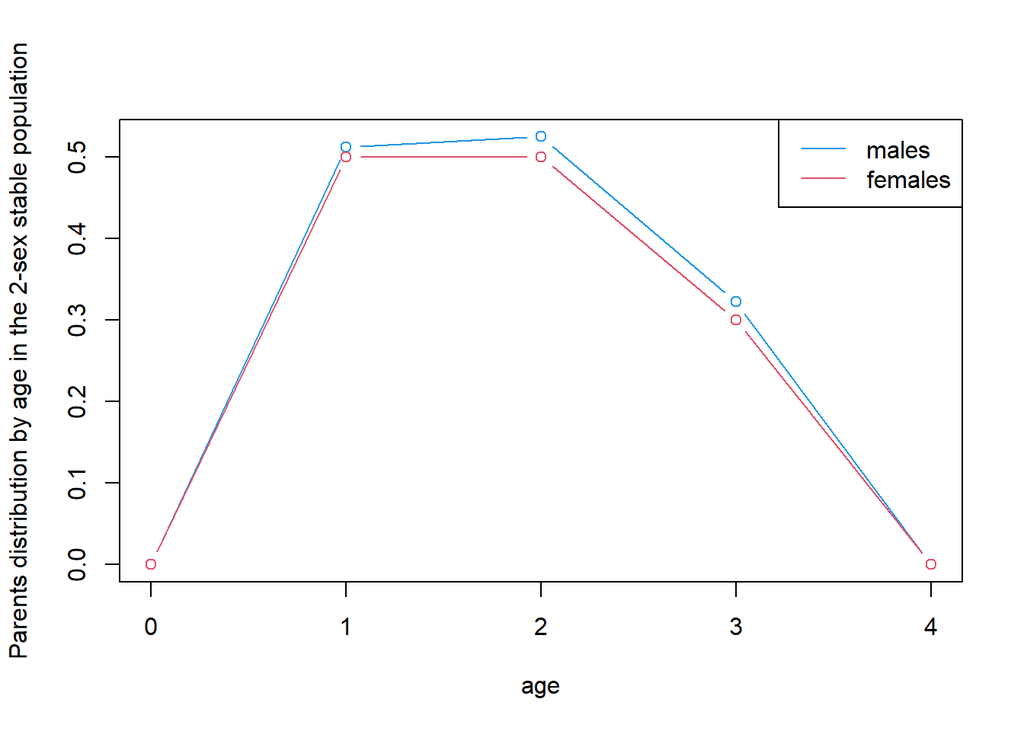

```r
age <- 0:4
# female
p_female <- c(.9, .7, .4, .1, 0)
f_female <- c(0, .5, .5, .3, 0)
# male
p_male <- c(.9, .6, .3, .05, 0) # higher mortality
f_male <- f_female * seq(1, 1.1, length.out = 5) # increase a bit level and mean age
plot(age, f_male, t="b", col = 4, ylab = "Parents distribution by age in the 2-sex stable population")
lines(age, f_female, t="b", col = 2)
legend("topright", c("males","females"), col=c(4,2), lty = 1)
```

Construyamos las matrices de supervivencia y fecundidad $U$ y $F$ para cada sexo.

```r
ages <- length(age)
# female
U_female <- F_female <- matrix(0, nrow=ages, ncol=ages)
U_female[row(U_female)-1 == col(U_female)] <- p_female[-ages]
U_female[ages, ages] <- p_female[ages]
F_female[1,] = f_female
# male
U_male = F_male = matrix(0, nrow=ages, ncol=ages)
U_male[row(U_male)-1 == col(U_male)] <- p_male[-ages]
U_male[ages, ages] = p_male[ages]
F_male[1,] = f_male
```

Caswell and Song (2021) sugiere mezclar los patrones femeninos y masculinos en matrices de bloque $Ub$ y $Fb$ (o $\tilde{U}$ y $\tilde{F}$ en el artículo), lo que nos permite proyectar un vector de población con los primeros 5 elementos correspondientes a la población femenina por edad y los últimos 5 para los hombres por edad (un vector estructurado en bloques, ver ec. 16 en Caswell (2022)).

El paquete `Matrix` nos ayudará a construir esas matrices de bloque (la función `bdiag` devuelve una matriz dispersa, por lo que hay que convertirla a una matriz común).

```r
alpha <- .5 # portion of males among offspring ()
Ub <- Matrix::bdiag(U_female, U_male) %>% as.matrix() # Ub in eq 9 Caswell (2021)
Fb <- rbind(cbind(alpha * F_female,      alpha * F_male), # Fb in eq 9 Caswell (2021)
            cbind((1-alpha) * F_female, (1-alpha) * F_male))
Ab <- Ub + Fb
```

> Estamos en un escenario en el que la supervivencia y la fecundidad no dependen de la línea de descendencia (es lo mismo para un nieto que proviene de hijas que de hijos). Lo mismo ocurre con las abuelas: no llevaremos un registro de si es la mamá del padre o la mamá de la madre. Esto se hace para simplificar el cálculo de matrices. Puedes cambiarlo según tu enfoque.

Proyectemos una población ficticia para ver cómo funcionan las matrices y vectores estructurados por bloques:

```r
set.seed(100)
pop_females <- rpois(5, 100)
pop_males <- rpois(5, 100)

# vector estructurado por bloques
popb <- c(pop_females, pop_males)

# proyección
pop_proj <- Ab %*% popb # sigue siendo un grafo cíclico conectado
pop_proj
```

```
##          [,1]
##  [1,] 131.125
##  [2,]  84.600
##  [3,]  58.800
##  [4,]  43.200
##  [5,]  10.100
##  [6,] 131.125
##  [7,]  84.600
##  [8,]  62.400
##  [9,]  28.800
## [10,]   5.000
```

Las posiciones 1 y 6 en el vector `pop_proj` corresponden a nuevos descendientes, y son iguales porque no importa cuántos individuos nuevos provengan de la fecundidad masculina y cuántos de la fecundidad femenina, todos se dividen por `$\alpha$`.

Así es como se proyecta una población de 2 sexos. Ahora encontremos la distribución estable por edad $w$, y luego las de los padres $pi$, para cada sexo:

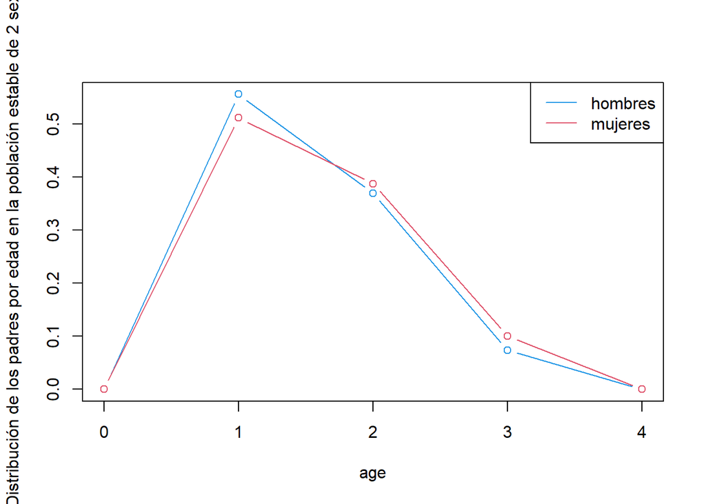

```r
A_eigen = eigen(Ab)
A_eigen_value = as.double(A_eigen$values[1])
A_eigen_vector = as.double(A_eigen$vectors[,1])
w_female = A_eigen_vector[1:ages]
w_male = A_eigen_vector[c((ages+1):(ages*2))] # recuerda la posición del sexo
pi_female = w_female * f_female / sum(w_female * f_female)
pi_male = w_male * f_male / sum(w_male * f_male)
pib <- c(pi_female, pi_male)
plot(age, pi_male, t="b", col = 4, ylab = "Distribución de los padres por edad en la población estable de 2 sexos")
lines(age, pi_female, t="b", col = 2)
legend("topright", c("hombres","mujeres"), col=c(4,2), lty = 1)
```

Ahora estamos preparados para proyectar los tipos de parentesco.

- **Madre**

Tenemos la distribución por edad de los padres cuando Focal nace $\tilde{d}(0)=\tilde{\pi}$ (eq 44), `pib` en nuestro código, que es la distribución inicial cuando Focal nace (primera columna de `Db`), y necesitamos proyectarlos como lo hicimos con la población ficticia.

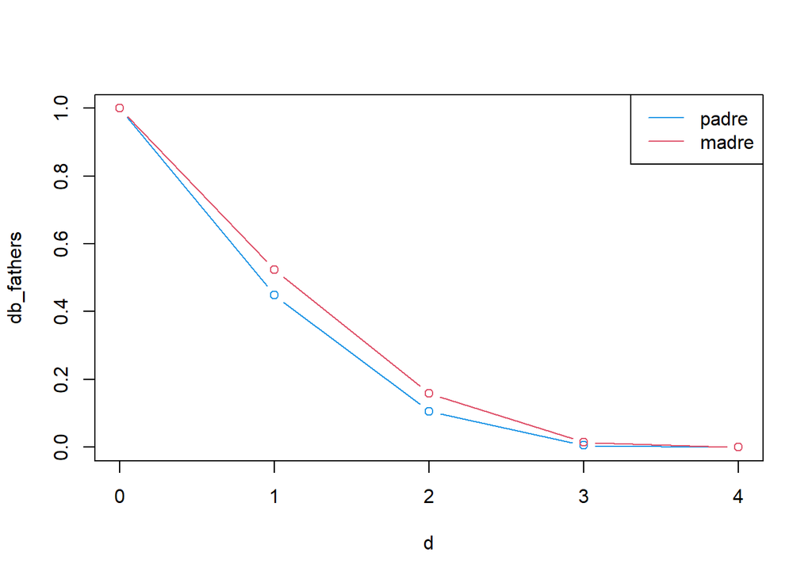

```r
# proyectar madres
Db <- matrix(0, ages*2, ages)
Db[,1] <- pib # eq 44 en Caswell (2022)
for(x in 2:ages){
  Db[,x] <- Ub %*% Db[,x-1] # eq 43 en Caswell (2022)
}

# podemos calcular el total de padres
ones = rep(1,ages*2) # vector fila por defecto
db <- ones %*% Db

# o específico por sexo
ones = rep(1,ages) # vector fila por defecto
db_mothers <- ones %*% Db[1:ages,]
db_fathers <- ones %*% Db[-(1:ages),]

# cuántas madres y padres vivos tiene Focal durante su vida
plot(age, db_fathers, t = "b", col = 4, xlab = "d")
lines(age, db_mothers, t = "b", col = 2)
legend("topright", c("padre","madre"), col =

 c(4,2), lty = 1)
```

> ¡Organizar las matrices y vectores de manera conveniente hizo que los cálculos fueran iguales al modelo de un solo sexo!
- **Hijos**

Para proyectar los hijos necesitamos una versión modificada de $E$ de la variante de un solo sexo, rastreando la edad de Focal en un vector estructurado por bloques: lo llamamos $Phi$ (eq. 34). Debido a que Focal es una mujer, comienza en la posición [1,1] (si no, comenzaría en [6,1]). La matriz $Gb$ mueve a Focal con la edad con una subdiagonal que también depende del sexo de Focal.

```r
Phi <- matrix(0, ages*2, ages)
Phi[1, 1] <- 1
# la matriz G mueve a Focal según la edad
G <- matrix(0, ages, ages)
G[row(G)-1 == col(G)] <- 1
Gb <- Matrix::bdiag(G, matrix(0, ages, ages)) %>% as.matrix()
```

Recuerda que para los hijos usamos $Fb$, por lo que todas las hijas provienen de la línea de Focal.

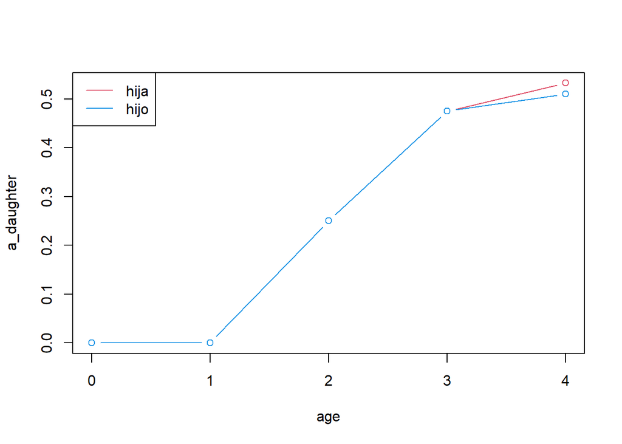

```r
# inicial
Ab <- matrix(0, ages*2, ages) # eq 36
for(x in 2:ages){
  Ab[,x]  = Ub %*% Ab[,x-1] + Fb %*% Phi[,x-1] # eq 35
  Phi[,x] = Gb %*% Phi[,x-1]
}
ones <- rep(1,5)
a_daughter <- ones %*% Ab[1:ages,]
a_son <- ones %*% Ab[-(1:ages),]

# cuántas hijas e hijos vivos tiene Focal durante su vida
plot(age, a_daughter, t = "b", col=2)
lines(age, a_son, t = "b", col = 4)
legend("topleft", c("hija","hijo"), col = c(2, 4), lty = 1)
```

Continuar con otros parientes sigue la misma lógica que el modelo de un solo sexo, pero con vectores y matrices estructurados por bloques, excepto dos excepciones. Para el caso de los descendientes, necesitamos asignar los nacimientos a uno de los padres, porque si no estaríamos contando dos veces a los hermanos jóvenes, por ejemplo (las tasas de fecundidad son independientes entre los sexos). Por convención, se asigna a la madre, reemplazando la fecundidad masculina de $\tilde{F}$ por $\tilde{F}^*$ (eq 57). La otra excepción es que para los ancestros, $\pi$ es la suma de la distribución femenina y masculina, debido a la falta de identificación de los abuelos por sexo de los que proviene la línea parental. Consulta la tabla de Caswell (2022) para un resumen.

#### Ejercicio

Replica este escenario invariante en el tiempo para los padres utilizando `Demokin`. Recuerda usar `pi_female` y `pi_male` como entradas, y establece `birth_female = .5` como asumimos:

**Mostrar**

```r
toy_ex <- kin2sex(p_female, p_male, f_female, f_male,  pif = pi_female, pim = pi_male, birth_female = .5)
toy_ex$kin_summary %>% filter(kin == "m") %>% arrange(sex_kin) %>% pull(count_living) -
c(db_mothers, db_fathers)
```

```
##  [1] 0 0 0 0 0 0 0 0 0 0
```

```r
toy_ex$kin_summary %>% filter(kin == "d") %>%
  summarise(count_living = sum(count_living), .by = c(age_focal, sex_kin)) %>% arrange(sex_kin) %>% pull(count_living) - c(a_daughter, a_son)
```

```
##  [1] 0 0 0 0 0 0 0 0 0 0
```

## Jueves 27

Durante esta sección veremos cómo aplicar los **modelos de parentesco de un solo sexo clasificados por etapa y edad invariantes en el tiempo** en R utilizando el paquete `DemoKin` y realizaremos algunos ejercicios.

- Usando DemoKin
- Ejercicios
- A mano

### Usando DemoKin

`DemoKin` permite el cálculo de estructuras de parentesco en un usando models ‘multiestado’ (‘multistate’), clasificando a los individuos según su edad y alguna otra característica (por ejemplo, etapas de una enfermedad). Para ello, necesitamos datos de mortalidad y fecundidad para cada etapa posible y probabilidades de transición entre etapas según la edad.

```r
library(DemoKin)
library(tidyr)
library(dplyr)
library(ggplot2)
library(knitr)
```

Consideremos el ejemplo de Eslovaquia dado por Caswell (2020), donde las etapas son estados de paridad. `DemoKin` incluye los datos para replicar este análisis para el año 1990. Tenga en cuenta que la función permite que el usuario ingrese listas para cada argumento (las listas debne ser consistente en sus dimensiones) o en un formato de data.frame para algunos argumentos. Los datos que vienen incluidos en DemoKin están en este formato (eche un vistazo en R):

- El data.frame `svk_fxs` es la probabilidad de reproducción en cada edad (filas) por cada etapa de paridad (columnas). La primera etapa representa desde la paridad=0 hasta 1; la segunda desde la paridad=1 hasta 2; y así sucesivamente, hasta que finalmente la sexta etapa representa desde la paridad=4 hasta 5 o más.
- El data.frame `svk_Hxs` tiene una estructura similar pero con $1$ en las edades correspondientes a los recién nacidos (la primera edad en nuestro ejemplo).
- El data.frame `svk_pxs` tiene la misma estructura y representa las probabilidades de supervivencia.
- La lista `svk_Uxs` tiene el mismo número de elementos y edades (en este caso 110 clases de edad). Para cada edad, contiene una matriz estocástica de transición con dimensiones que corresponded al espacio de los estados. Las entradas son probabilidades de transición condicionales a la supervivencia.

Con la función `kin_multi_stage` podemos obtener la estructura conjunta de edad-paridad en un marco temporal invariante. La funcion solo devolverá la data frame `kin_full` (es decir, `kin_summary` no esta disponible). Por ahora, ejecute el modelo y examine la salida, nos adentraremos en los detalles en la siguiente sección:

```r
# use birth_female=1 because fertility is for female only
demokin_svk1990 <-
  kin_multi_stage(
    U = svk_Uxs,
    f = svk_fxs,
    D = svk_pxs,
    H = svk_Hxs,
    birth_female=1)
head(demokin_svk1990)
```

```
## # A tibble: 6 × 6
##   kin   age_kin stage_kin age_focal living  dead
##   <chr>   <dbl>     <int>     <int>  <dbl> <dbl>
## 1 focal       0         1         0      1     0
## 2 focal       0         1         1      0     0
## 3 focal       0         1         2      0     0
## 4 focal       0         1         3      0     0
## 5 focal       0         1         4      0     0
## 6 focal       0         1         5      0     0
```

Como ejemplo, consideremos la distribución de edad-paridad de las tías, cuando Focal tiene 20 y 60 años (similar a la Figura 4 de Caswell [2021]).

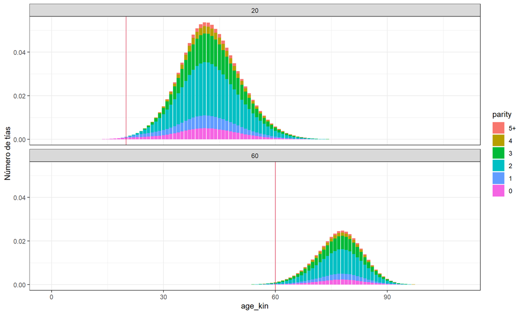

```r
demokin_svk1990 %>%
  filter(kin %in% c("oa","ya"), age_focal %in% c(20,60)) %>%
  mutate(parity = as.integer(stage_kin)-1,
         parity = case_when(parity == 5 ~ "5+", T ~ as.character(parity)),
         parity = forcats::fct_rev(parity)) %>%
  group_by(age_focal, age_kin, parity) %>%
  summarise(count= sum(living)) %>%
  ggplot() +
  geom_bar(aes(x=age_kin, y = count, fill=parity), stat = "identity") +
  geom_vline(aes(xintercept = age_focal), col=2) +
  labs(y = "Número de tías") +
  theme_bw() +
  facet_wrap(~age_focal, nrow = 2)
```

También podemos ver la proporción de hijas y madres vivas en diferentes etapas de paridad a lo largo de la vida de Focal (esto es equivalente a la Figura 9 y 10 en Caswell [2021]).

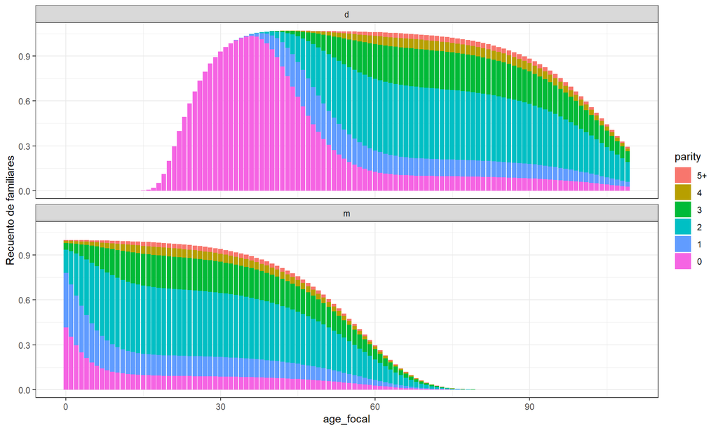

```r
demokin_svk1990 %>%
  filter(kin %in% c("d","m")) %>%
  mutate(parity = as.integer(stage_kin)-1,
         parity = case_when(parity == 5 ~ "5+", T ~ as.character(parity)),
         parity = forcats::fct_rev(parity)) %>%
  group_by(age_focal, kin, parity) %>%
  summarise(count= sum(living)) %>%
  DemoKin::rename_kin() %>%
  ggplot() +
  geom_bar(aes(x=age_focal, y = count, fill=parity), stat = "identity") +
  labs(y = "Recuento de familiares") +
  theme_bw() +
  facet_wrap(~kin, nrow = 2)
```

**Piensa**: ¿Qué otros tipos de indicadores podrian ser interesantes para modelos mutiestado?

### Ejercicios

Ahora vamos a obtener los datos, construir las listas necesarias y ejecutar un modelo multiestado. Debe elegir su propio país de entre los paises que tienen tasas de fecundidad por paridad. Estos paises estan disponibles en el archivo de datos *“data/fert_cond.Rdata”*, que se obtuvo de HFD. Luego, obtenga la probabilidad de supervivencia de la ONU (asumiremos que la mortalidad es la misma para todas las etapas de paridad). Recuerde que vamos a aplicar el modelo en un marco de tiempo invariante de un solo sexo, así que elija un año para el país.

Para mostrar paso a paso, aquí hay un ejemplo con los Estados Unidos de América. Primero, obtenemos las tasas en cada paridad (por ejemplo, `m1x` es la tasa de transición de paridad 0 a 1).

```r
# fertility by parity
load("../data/fert_cond.Rdata")
cond_fert_usa2015 <- fert_cond %>%
  filter(Code == "USA", Year == 2015) %>%
  select(m1x:m5px)
```

Luego obtenga la supervivencia con el mismo número de columnas.

```r
# mortality (replicate same for each column of fertility data)
source("../docs/get_UNWPP_inputs.R")
data_usa_2015 <- get_UNWPP_inputs(
  countries = "United States of America",
  my_startyr = 2015,
  my_endyr = 2015)
```

```
## [1] "Getting API ready..."
## [1] "Make sure you have a working internet connection!"
## [1] "Getting mortality data for United States of America"
## [1] "Getting fertility data for United States of America"
```

```r
usa_2015_surv <- data_usa_2015 %>%
  select(px1 = px) %>%
  mutate(px2 = px1, px3 = px1, px4 = px1, px5 = px1)
```

Cargue las funciones guardadas en el archivo *“docs/kin_multi_stage.R”* para traducir los datos a un formato de lista y usarlos como entradas en la función `DemoKin`.

```r
source("../docs/kin_multi_stage.R")
# create lists
lists_usa2015 <- make_mulstistate_parity_matrices(f_parity = cond_fert_usa2015,
                                                  p_parity = usa_2015_surv)
```

Acaba de crear las listas necesarias. Ejecute el modelo:

```r
# run model
usa_2015_kin_parity <-
  kin_multi_stage(
    U = lists_usa2015[["U"]],
    f = lists_usa2015[["F."]],
    D = lists_usa2015[["D"]],
    H = lists_usa2015[["H"]],
    birth_female=1)
```

Considere la distribución de edad-paridad de las hermanas cuando Focal tiene 20 y 60 años:

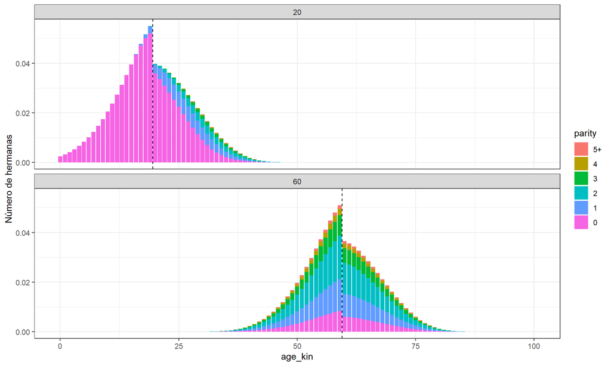

```r
usa_2015_kin_parity %>%
  filter(kin %in% c("os","ys"), age_focal %in% c(20,60)) %>%
  mutate(parity = as.integer(stage_kin)-1,
         parity = case_when(parity == 5 ~ "5+", T ~ as.character(parity)),
         parity = forcats::fct_rev(parity)) %>%
  group_by(age_focal, age_kin, parity) %>%
  summarise(count= sum(living)) %>%
  ggplot() +
  geom_bar(aes(x=age_kin, y = count, fill=parity), stat = "identity") +
  geom_vline(aes(xintercept = age_focal-.5), col=1, linetype=2) +
  labs(y = "Número de hermanas") +
  theme_bw() +
  facet_wrap(~age_focal, nrow = 2)
```

Ahora, con su país, realice los mismos pasos y luego **responda**:

**E1**. ¿Cuál es la distribución de madres vivas por paridad cuando Focal tiene 30 años?

**E2**. ¿Cuál es la edad media de las hijas por paridad cuando Focal tiene 60 años?

**E3**. Elija un gráfico en el artículo de Caswell (2020) e intente reproducirlo.